# Part II - Data Expo 2009: Airline on time data

## by Joseph Abang

## Investigation Overview

> The analysis' findings are divided into three categories: flight information(counts),flight information(delays) and carrier information. Each insight begins with a response to a question that touches on all of these categories, followed by the sharing of two additional insightful ideas that don't fall into any of the categories. A few simple questions, some of which are listed below, yielded all of the important insights.
> - Are there more flights on weekends?
> - How consistent are daily flight totals?
> - When is the best day of the week to fly and arrive on time?
> - When are the most late arrivals and departures at airports?
> - Which airline is best known for its short, medium, and long-distance flights?
> - Which airline is the most popular?

> This presentation's objective is to display visualizations that support the conclusions drawn from an analysis of the "Data Expo 2009: Airline on Time Data."

## Dataset Overview

> A sample of 200,000 records from each year between 1987 and 2008 made up the gathered data set. I removed unused columns, deleted duplicates, and dropped null values during the wrangling process. Additionally, I added new columns (dummy variables) to facilitate exploration and performed transformations (merging, changing data types) on a few columns. The clean and dataset spans the years 1995 to 2008 and includes 11 columns and 2,730,250 values.

### Flight information (counts)

- Are there more flights on weekends?
- How consistent are daily flight totals?

> **Weekly flights** show a steady number of flights during weekdays (Monday-Friday) and a slight decrease in the number of flights on weekends.

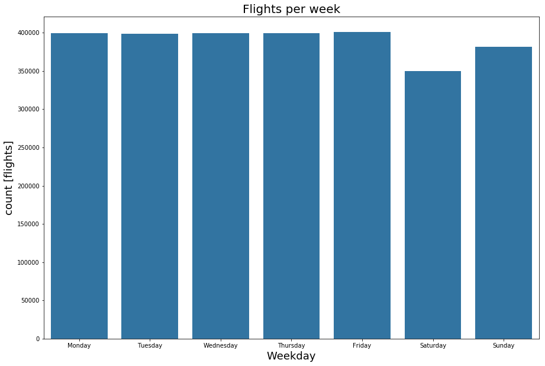

> **Daily flights** show that the last few days of the month see a sharp decline in flight demand.

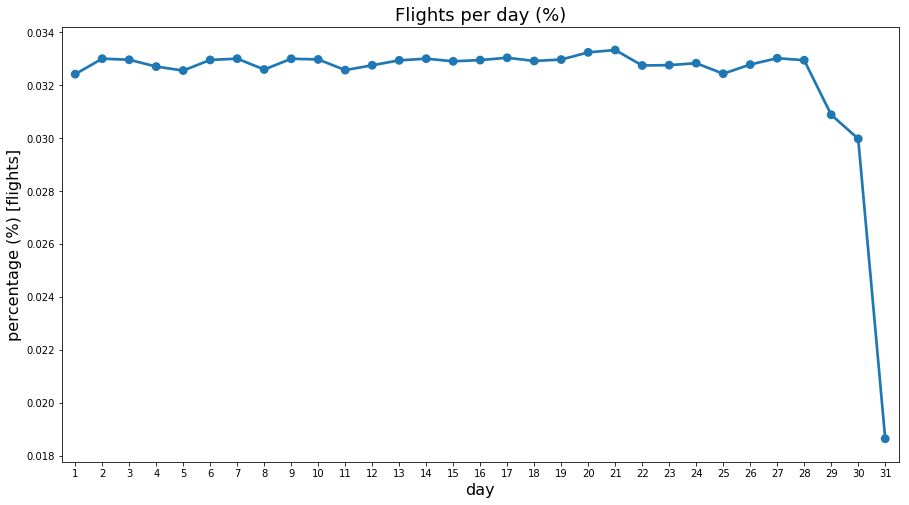

### Flight information (delays)

- When is the best day of the week to fly and arrive on time?
- What percentage of flights are late flights?

### Weekday delays

> The majority of on-time flight records occur on Tuesday. The most late arrivals/departures occur on Thursdays and Fridays.

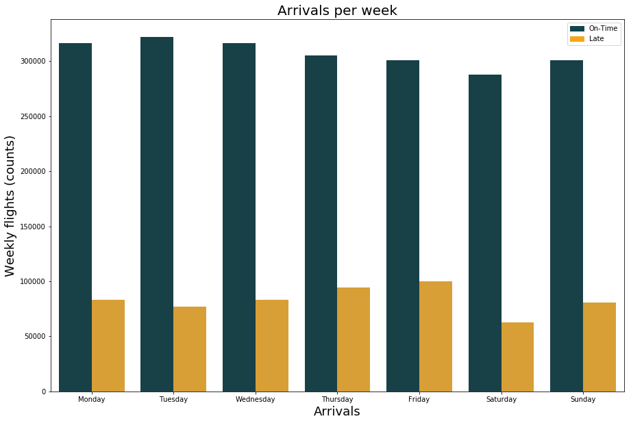

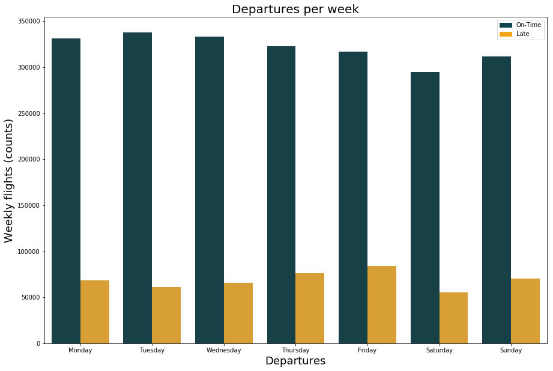

### Arrivals

> 78.7% of flights arrive on time, leaving 21.3% of arrival flights **Late**.

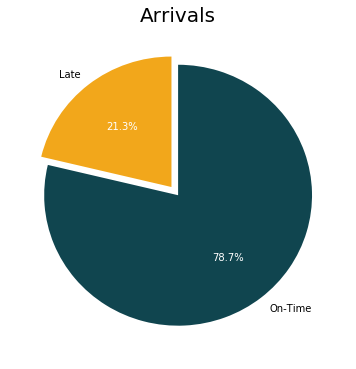

## Carrier information

- Which airline is best known for its short, medium, and long-distance flights?
- Which airline is the most popular?

### Popular carriers according to frequency:

> 9 Air (AQ), the carrier with the lowest frequency, is the least popular, and **Southwest Airlines (WN)**, the carrier with the highest frequency, is the most popular.

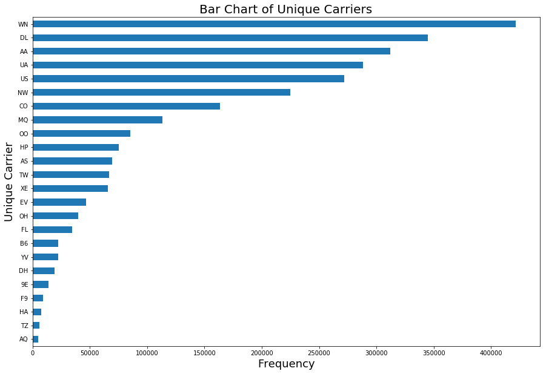

### Most popular carriers according to flight lengths are:

> Short-haul flights under 600 miles are most frequently flown by **Southwest Airlines (WN)**, while medium- (under 3000 Miles) and long-haul flights(greater than 3000 Miles) are most frequently flown by **American Airlines (AA).**

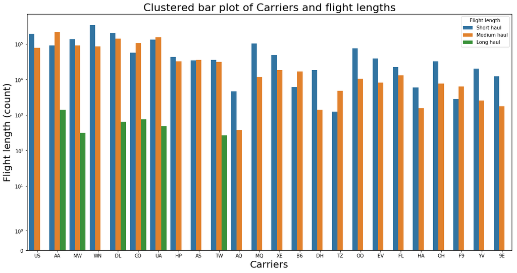

### Interesting insight (i)

> There was a significant correlation between distance and airtime. The longer the carrier is in the air, the further the destination is; **airtime increases as distance increases.**

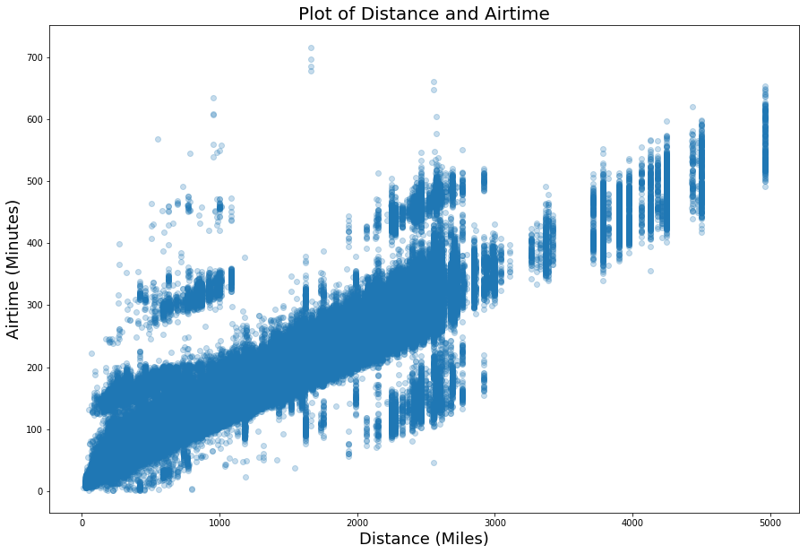

### Interesting insight (ii)

> In comparison to on-time arrivals, late arrivals have a marginally higher airtime value. There are many potential causes for this, including the weather or technical difficulties. **Airtime should therefore be taken into account when there are delays in arrival.**

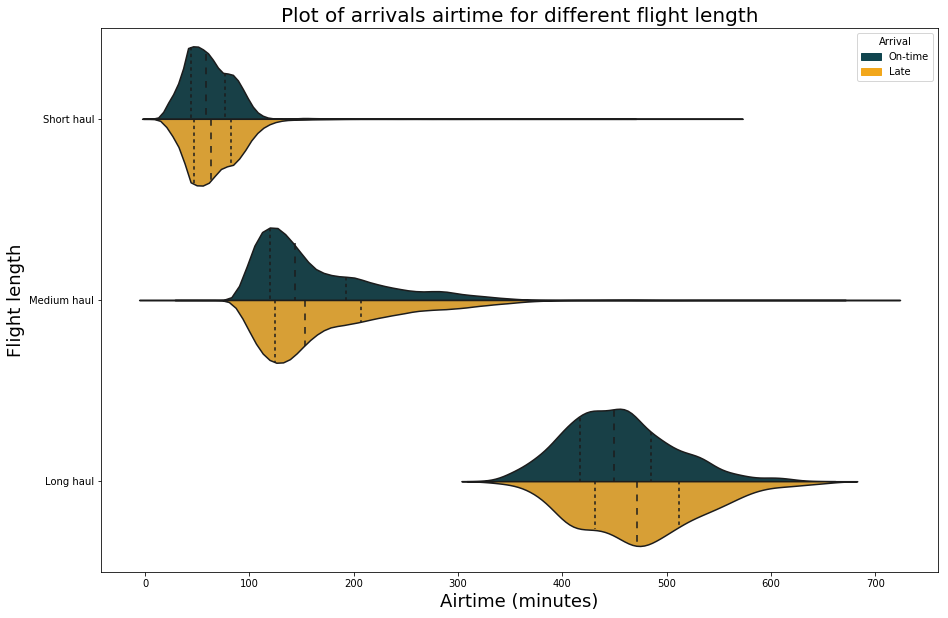